# Using Genexpi from R

This notebook will guide you through using Genexpi from R.

# Setting up

```r
  develRun = FALSE;
  # Helper function to install packages if they are not available
  pkgTest <- function(x)
  {
    if (!require(x,character.only = TRUE))
    {
      install.packages(x,dep=TRUE)
        if(!require(x,character.only = TRUE)) stop("Package not found")
    }
  }
  # Install and load Genexpi from GitHub vie devtools
  if(!develRun) {
    pkgTest("devtools")
    install_github("cas-bioinf/genexpi", subdir="rpackage")
  }
  # ggplot is not strictly required by Genexpi, but will be useful in this workflow
  pkgTest("ggplot2")
```

Genexpi relies on OpenCL, so we need to check the available OpenCL devices:

```r
listOpenCLDevices()
```

```
[1] "Intel(R) HD Graphics 530 (Intel(R) OpenCL)"
[2] "Intel(R) Core(TM) i7-6700K CPU @ 4.00GHz (Intel(R) OpenCL)"
[3] "gfx804 (AMD Accelerated Parallel Processing)"
[4] "Intel(R) Core(TM) i7-6700K CPU @ 4.00GHz (AMD Accelerated Parallel Processing)"
[5] "Intel(R) Core(TM) i7-6700K CPU @ 4.00GHz (Experimental OpenCL 2.0 CPU Only Platform)"
[6] "Oclgrind Simulator (Oclgrind)"
[7] "GeForce GTX 960 (NVIDIA CUDA)"
```

If the list is empty or the call ends in an error, it is probably because your computer has no OpenCL driver installed. Almost all recent GPUs and CPUs (processors) support OpenCL, so you should be able to run Genexpi.

- For GPUs, try updating your device driver. We also encountered cases where GPUs started being available only after installing a CPU driver (see next bullet).
- For CPUs (the usual processors), you need to install specific drivers. As of 2017-05-22, drivers for Intel CPUs can be downloaded at https://software.intel.com/en-us/articles/opencl-drivers#latest_CPU_runtime - (you want “runtime-only”). AMD’s drivers can be found at http://support.amd.com/en-us/kb-articles/Pages/OpenCL2-Driver.aspx.

If the list is non-empty, you can choose which device to use for computation. The best devices to use with Genexpi are (in the following order):

- A dedicated graphics card (GPU) for computing (not connected to a display)
- A Xeon Phi card
- Your processor (CPU)
- A GPU connected to a display

While GPUs will run Genexpi the fastest, using a GPU connected to a display is discouraged as it interferes with the operating system (OS) and may cause your computer to freeze and/or the computations to be reset by the operating system. If you absolutely need to use the GPU running your display, and use Windows, you may want to disable TDR - Timeout detection and recovery (expert only).

With that in mind, let us select a device.

```r
#Select the device automatically
deviceSpecs = getDeviceSpecs()
#Select the best GPU device
#deviceSpecs = getDeviceSpecs(deviceType = "gpu")
#Select the best CPU device
#deviceSpecs = getDeviceSpecs(deviceType = "processor")
#Select device by ID reported in listOpenCLDevices()
deviceSpecs = getDeviceSpecs(device = 7)
#Display the selected device
if(is.null(deviceSpecs)) {
  stop("Invalid device")
} else {
  paste0("Using device: ",getJavaDeviceSpecs(deviceSpecs)$getDevice()$toString())
}
```

```
[1] "Using device: GeForce GTX 960 (NVIDIA CUDA)"
```

# Determining regulons

First let’s prepare some small data

```r
#Let's start with some simple data - this is a small subset of GSE6865 (B. subtilis), rows correspond to genes, columns to time
d = rbind(
c(0.06502849,0.12641291,4.27290048,5.84100134,3.82700481,4.21407420,3.65587239,3.02349190,2.25201387,0.77122072,1.62474771,1.46329000,2.06367490,1.63831834),
c(0.09842821,0.08544949,2.3009278,2.9818666,2.4712067,4.341567,3.961964,2.289791,2.375474,1.302439,1.501304,1.471427,1.932162,1.365298),
c(0.14114165,0.59965961,14.7763262,10.6310760,9.5547340,4.408280,3.439540,4.630653,2.886289,6.463053,5.845051,3.942787,4.463625,6.051177),
c(0.08616320,0.04863760,0.08988447,0.05245469,0.10282163,0.16078622,0.08568674,0.27228996,0.34298460,0.27172434,0.12826645,0.18227842,0.22628545,0.16703423)
)
rownames(d) = c("sigA","codY","dnaA","aldY");
time = c(0,5,10,15,20,25,30,40,50,60,70,80,90,100) #Time in minutes for the individual samples
```

## Smoothing data

Genexpi workflow starts with smoothing the data. We can inspect whether the chosen degrees of freedom (DF) represent the data well.

```
sigA - orange
dnaA - blue
codY - green
aldY - black
```

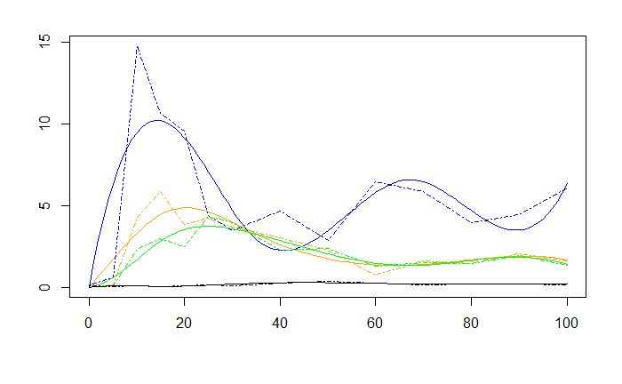

```r
time_smooth = 0:100 #Genexpi requires uniform intervals between data points
data_smooth = splineProfileMatrix(d, time, time_smooth, df = 6)
#We can check how well does the smooth data approximate the raw data by plotting the raw and smoothed data together
inspectSmoothing(time, d, time_smooth, data_smooth, c("sigA","dnaA","codY","aldY"))
```

## The default (simple way)

Once the data is smoothed, the whole genexpi workflow can now be run via a single command:

```r
regulonNames = c("codY", "dnaA", "aldY")
result = computeRegulon(deviceSpecs = deviceSpecs, profiles = data_smooth, regulatorName = "sigA", regulonNames = regulonNames)
```

```
Allocating 0MB.
Preparation took: 20.829515 ms.
Computation took: 426.5912 ms.
Allocating 0MB.
Preparation took: 6.240066 ms.
Computation took: 561.6701 ms.
```

```r
cat("Regulated:", rownames(data_smooth)[result$regulated], "\n")
```

```
Regulated: codY
```

```r
cat("Not regulated:", rownames(data_smooth)[result$tested & !result$regulated])
```

```
Not regulated: dnaA
```

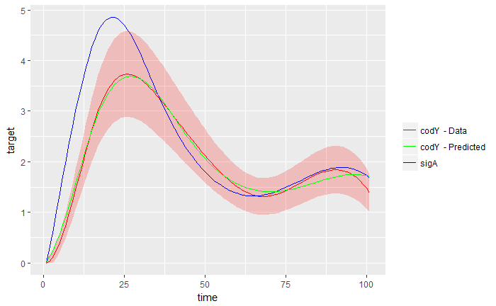

```r
inspectRegulonFit(result,"codY")
```

Inspecting the fit, we see the error band. The width of the error band can be modified by setting the `errorDef` parameter - see below for more info.

The `result` contains also other information gathered during the workflow:

```r
#The number of genes fitted by the no change model
result$numConstant
```

```
[1] 0
```

```r
#The actual genes (boolean indexer into the profile matrix)
rownames(data_smooth)[result$constant]
```

```
character(0)
```

```r
#The number of genes fitted by the constant synthesis model
result$numConstantSynthesis
```

```
[1] 1
```

```r
#The actual genes
rownames(data_smooth)[result$constantSynthesis]
```

```
[1] "aldY"
```

```r
#The genes tested by Genexpi (the regulon after removing constant and constant synthesis)
result$numTested
```

```
[1] 2
```

```r
rownames(data_smooth)[result$tested]
```

```
[1] "codY" "dnaA"
```

```r
#The genes tested for constant synthesis (indices into the profile matrix)
rownames(data_smooth)[result$constantSynthesisResults$tasks]
```

```
[1] "codY" "dnaA" "aldY"
```

```r
#The parameters of the constant synthesis best fit (even for genes, that eventually were not fit) - rows correspond to the tasks above
result$constantSynthesisResults$parameters
```

```
      synthesis      decay
[1,] 0.41473317 0.18754339
[2,] 3.40878487 0.62639838
[3,] 0.01202372 0.05345187
```

```r
#The regulator-target pairs tested for actual regulation (indices into the profile matrix)
result$regulationResults$tasks
```

```
     [,1] [,2]
[1,]    1    2
[2,]    1    3
```

```r
#The parameters of the best fits (rows correspond to the tasks above)
result$regulationResults$parameters
```

```
             k1        k2          b         w
[1,]  0.9339381 0.1997888 -1.7939947 0.6930449
[2,] 12.6965609 1.1486509 -0.8014403 0.3111537
```

## Invoking individual workflow steps manually

We can also invoke the individual workflow steps manually. Let’s start with constant profiles

```r
#First find out the constant profiles
testConstant(data_smooth)
```

```
 sigA  codY  dnaA  aldY
FALSE FALSE FALSE FALSE
```

```r
#All functions support an optional errorDef argument to specify the error margins:
errorDef = defaultErrorDef()
errorDef
```

```
$absolute
[1] 0.1

$relative
[1] 0.2

$minimal
[1] 0
```

```r
#Let's increase the minimal error to 0.5 (which is sensible for the given data)
errorDef$minimal = 0.5
#With this error margin, aldY starts to be considered constant
testConstant(data_smooth, errorDef = errorDef)
```

```
 sigA  codY  dnaA  aldY
FALSE FALSE FALSE  TRUE
```

Now we can handle constant synthesis.

```r
#Now compute constant synthesis fits. Tasks specifies the rows of the profile matrix for which constant synthesis is computed
constantSynthResults = computeConstantSynthesis(deviceSpecs, d, tasks = c(1,4))
```

```
Allocating 0MB.
Preparation took: 2.307578 ms.
Computation took: 176.49878 ms.
```

```r
#The fit parameters are
constantSynthResults$parameters
```

```
      synthesis      decay
[1,] 3.49945569 1.25798690
[2,] 0.02452051 0.08465658
```

```r
#We can test whether the profiles defined by the parameters fall within the error margin
constProfiles = testConstantSynthesis(constantSynthResults, errorDef =  errorDef, minFitQuality = 0.8)
#The return value can be used to index the profile matrix
rownames(d)[constProfiles]
```

```
[1] "aldY"
```

And finally the fitting of regulator interactions

```r
#We test regulation of genes 2 and 4 (codY, aldY) by gene 1 (sigA)
tasks = rbind(c(1,2), c(1,4))
additiveResult = computeAdditiveRegulation(deviceSpecs, data_smooth, tasks)
```

```
Allocating 0MB.
Preparation took: 2.322652 ms.
Computation took: 536.2518 ms.
```

```r
#Once again we can see the parameters
additiveResult$parameters
```

```
             k1         k2         b         w
[1,] 0.86088926 0.20223492 -1.870923 0.8221378
[2,] 0.01152715 0.00894634 -6.336440 2.0488524
```

```r
#And we can test whether the profiles fit within the error margin
testResults = testAdditiveRegulation(additiveResult, errorDef = errorDef, minFitQuality = 0.8 )
#And show the tasks corresponding to regulations (in this case both)
tasks[testResults$regulatedTasks,]
```

```
     [,1] [,2]
[1,]    1    2
[2,]    1    4
```

# Other use cases

To test fits with multiple regulators, we just need to expand the tasks array with additional columns. Here, we try to fit dnaA, by combining sigA with either aldY or codY

```r
tasks2 = rbind(c(1,2,3), c(1,4,3))
additiveResult = computeAdditiveRegulation(deviceSpecs, data_smooth, tasks = tasks2)
```

```
Allocating 0MB.
Preparation took: 3.211753 ms.
Computation took: 579.75256 ms.
```

```r
tasks2[testResults$regulatedTasks,]
```

```
     [,1] [,2] [,3]
[1,]    1    2    3
[2,]    1    4    3
```